# Risk Factor Analysis

## Outcome Variable

**Outcome Variable:** y_rate_len

## Predictor Variables

**Intervention Variable:** vagbrth

**Adjustment Set:**

unadjusted

## Stratifying Variables

The analysis was stratified on these variable(s):

- agecat
- studyid
- country

## Data Summary

| agecat | studyid | country | vagbrth | n_cell | n |
| --- | --- | --- | --- | --- | --- |
| 0-3 months | ki1000108-CMC-V-BCS-2002 | INDIA | 0 | 10 | 87 |
| 0-3 months | ki1000108-CMC-V-BCS-2002 | INDIA | 1 | 77 | 87 |
| 0-3 months | ki1000108-IRC | INDIA | 0 | 66 | 377 |
| 0-3 months | ki1000108-IRC | INDIA | 1 | 311 | 377 |
| 0-3 months | ki1017093b-PROVIDE | BANGLADESH | 0 | 148 | 634 |
| 0-3 months | ki1017093b-PROVIDE | BANGLADESH | 1 | 486 | 634 |
| 0-3 months | ki1017093c-NIH-Crypto | BANGLADESH | 0 | 193 | 469 |
| 0-3 months | ki1017093c-NIH-Crypto | BANGLADESH | 1 | 276 | 469 |
| 0-3 months | ki1119695-PROBIT | BELARUS | 0 | 1424 | 12745 |
| 0-3 months | ki1119695-PROBIT | BELARUS | 1 | 11321 | 12745 |
| 0-3 months | ki1126311-ZVITAMBO | ZIMBABWE | 0 | 683 | 7802 |
| 0-3 months | ki1126311-ZVITAMBO | ZIMBABWE | 1 | 7119 | 7802 |
| 0-3 months | kiGH5241-JiVitA-3 | BANGLADESH | 0 | 1704 | 40020 |
| 0-3 months | kiGH5241-JiVitA-3 | BANGLADESH | 1 | 38316 | 40020 |
| 0-3 months | kiGH5241-JiVitA-4 | BANGLADESH | 0 | 200 | 3610 |
| 0-3 months | kiGH5241-JiVitA-4 | BANGLADESH | 1 | 3410 | 3610 |
| 3-6 months | ki1000108-CMC-V-BCS-2002 | INDIA | 0 | 21 | 307 |
| 3-6 months | ki1000108-CMC-V-BCS-2002 | INDIA | 1 | 286 | 307 |
| 3-6 months | ki1000108-IRC | INDIA | 0 | 67 | 397 |
| 3-6 months | ki1000108-IRC | INDIA | 1 | 330 | 397 |
| 3-6 months | ki1017093b-PROVIDE | BANGLADESH | 0 | 133 | 574 |
| 3-6 months | ki1017093b-PROVIDE | BANGLADESH | 1 | 441 | 574 |
| 3-6 months | ki1017093c-NIH-Crypto | BANGLADESH | 0 | 182 | 443 |
| 3-6 months | ki1017093c-NIH-Crypto | BANGLADESH | 1 | 261 | 443 |
| 3-6 months | ki1066203-TanzaniaChild2 | TANZANIA, UNITED REPUBLIC OF | 0 | 159 | 1641 |
| 3-6 months | ki1066203-TanzaniaChild2 | TANZANIA, UNITED REPUBLIC OF | 1 | 1482 | 1641 |
| 3-6 months | ki1119695-PROBIT | BELARUS | 0 | 1473 | 13309 |
| 3-6 months | ki1119695-PROBIT | BELARUS | 1 | 11836 | 13309 |
| 3-6 months | ki1126311-ZVITAMBO | ZIMBABWE | 0 | 509 | 5842 |
| 3-6 months | ki1126311-ZVITAMBO | ZIMBABWE | 1 | 5333 | 5842 |
| 3-6 months | kiGH5241-JiVitA-3 | BANGLADESH | 0 | 1538 | 25100 |
| 3-6 months | kiGH5241-JiVitA-3 | BANGLADESH | 1 | 23562 | 25100 |
| 3-6 months | kiGH5241-JiVitA-4 | BANGLADESH | 0 | 256 | 3524 |
| 3-6 months | kiGH5241-JiVitA-4 | BANGLADESH | 1 | 3268 | 3524 |
| 6-12 months | ki1000108-CMC-V-BCS-2002 | INDIA | 0 | 22 | 323 |
| 6-12 months | ki1000108-CMC-V-BCS-2002 | INDIA | 1 | 301 | 323 |
| 6-12 months | ki1000108-IRC | INDIA | 0 | 68 | 400 |
| 6-12 months | ki1000108-IRC | INDIA | 1 | 332 | 400 |
| 6-12 months | ki1017093b-PROVIDE | BANGLADESH | 0 | 121 | 545 |
| 6-12 months | ki1017093b-PROVIDE | BANGLADESH | 1 | 424 | 545 |
| 6-12 months | ki1017093c-NIH-Crypto | BANGLADESH | 0 | 176 | 420 |
| 6-12 months | ki1017093c-NIH-Crypto | BANGLADESH | 1 | 244 | 420 |
| 6-12 months | ki1066203-TanzaniaChild2 | TANZANIA, UNITED REPUBLIC OF | 0 | 102 | 1065 |
| 6-12 months | ki1066203-TanzaniaChild2 | TANZANIA, UNITED REPUBLIC OF | 1 | 963 | 1065 |
| 6-12 months | ki1119695-PROBIT | BELARUS | 0 | 1444 | 12896 |
| 6-12 months | ki1119695-PROBIT | BELARUS | 1 | 11452 | 12896 |
| 6-12 months | ki1126311-ZVITAMBO | ZIMBABWE | 0 | 369 | 4533 |
| 6-12 months | ki1126311-ZVITAMBO | ZIMBABWE | 1 | 4164 | 4533 |
| 6-12 months | kiGH5241-JiVitA-3 | BANGLADESH | 0 | 1182 | 19606 |
| 6-12 months | kiGH5241-JiVitA-3 | BANGLADESH | 1 | 18424 | 19606 |
| 6-12 months | kiGH5241-JiVitA-4 | BANGLADESH | 0 | 474 | 5610 |
| 6-12 months | kiGH5241-JiVitA-4 | BANGLADESH | 1 | 5136 | 5610 |
| 12-24 months | ki1000108-CMC-V-BCS-2002 | INDIA | 0 | 23 | 324 |
| 12-24 months | ki1000108-CMC-V-BCS-2002 | INDIA | 1 | 301 | 324 |
| 12-24 months | ki1000108-IRC | INDIA | 0 | 67 | 396 |
| 12-24 months | ki1000108-IRC | INDIA | 1 | 329 | 396 |
| 12-24 months | ki1017093b-PROVIDE | BANGLADESH | 0 | 101 | 458 |
| 12-24 months | ki1017093b-PROVIDE | BANGLADESH | 1 | 357 | 458 |
| 12-24 months | ki1017093c-NIH-Crypto | BANGLADESH | 0 | 94 | 241 |
| 12-24 months | ki1017093c-NIH-Crypto | BANGLADESH | 1 | 147 | 241 |
| 12-24 months | ki1066203-TanzaniaChild2 | TANZANIA, UNITED REPUBLIC OF | 0 | 1 | 2 |
| 12-24 months | ki1066203-TanzaniaChild2 | TANZANIA, UNITED REPUBLIC OF | 1 | 1 | 2 |
| 12-24 months | ki1119695-PROBIT | BELARUS | 0 | 298 | 2533 |
| 12-24 months | ki1119695-PROBIT | BELARUS | 1 | 2235 | 2533 |
| 12-24 months | ki1126311-ZVITAMBO | ZIMBABWE | 0 | 20 | 297 |
| 12-24 months | ki1126311-ZVITAMBO | ZIMBABWE | 1 | 277 | 297 |
| 12-24 months | kiGH5241-JiVitA-3 | BANGLADESH | 0 | 524 | 9252 |
| 12-24 months | kiGH5241-JiVitA-3 | BANGLADESH | 1 | 8728 | 9252 |
| 12-24 months | kiGH5241-JiVitA-4 | BANGLADESH | 0 | 513 | 6223 |
| 12-24 months | kiGH5241-JiVitA-4 | BANGLADESH | 1 | 5710 | 6223 |

The following strata were considered:

- agecat: 0-3 months, studyid: ki1000108-CMC-V-BCS-2002, country: INDIA
- agecat: 0-3 months, studyid: ki1000108-IRC, country: INDIA
- agecat: 0-3 months, studyid: ki1017093b-PROVIDE, country: BANGLADESH
- agecat: 0-3 months, studyid: ki1017093c-NIH-Crypto, country: BANGLADESH
- agecat: 0-3 months, studyid: ki1119695-PROBIT, country: BELARUS
- agecat: 0-3 months, studyid: ki1126311-ZVITAMBO, country: ZIMBABWE
- agecat: 0-3 months, studyid: kiGH5241-JiVitA-3, country: BANGLADESH
- agecat: 0-3 months, studyid: kiGH5241-JiVitA-4, country: BANGLADESH
- agecat: 12-24 months, studyid: ki1000108-CMC-V-BCS-2002, country: INDIA
- agecat: 12-24 months, studyid: ki1000108-IRC, country: INDIA
- agecat: 12-24 months, studyid: ki1017093b-PROVIDE, country: BANGLADESH
- agecat: 12-24 months, studyid: ki1017093c-NIH-Crypto, country: BANGLADESH
- agecat: 12-24 months, studyid: ki1066203-TanzaniaChild2, country: TANZANIA, UNITED REPUBLIC OF
- agecat: 12-24 months, studyid: ki1119695-PROBIT, country: BELARUS
- agecat: 12-24 months, studyid: ki1126311-ZVITAMBO, country: ZIMBABWE
- agecat: 12-24 months, studyid: kiGH5241-JiVitA-3, country: BANGLADESH
- agecat: 12-24 months, studyid: kiGH5241-JiVitA-4, country: BANGLADESH
- agecat: 3-6 months, studyid: ki1000108-CMC-V-BCS-2002, country: INDIA
- agecat: 3-6 months, studyid: ki1000108-IRC, country: INDIA
- agecat: 3-6 months, studyid: ki1017093b-PROVIDE, country: BANGLADESH
- agecat: 3-6 months, studyid: ki1017093c-NIH-Crypto, country: BANGLADESH
- agecat: 3-6 months, studyid: ki1066203-TanzaniaChild2, country: TANZANIA, UNITED REPUBLIC OF
- agecat: 3-6 months, studyid: ki1119695-PROBIT, country: BELARUS
- agecat: 3-6 months, studyid: ki1126311-ZVITAMBO, country: ZIMBABWE
- agecat: 3-6 months, studyid: kiGH5241-JiVitA-3, country: BANGLADESH
- agecat: 3-6 months, studyid: kiGH5241-JiVitA-4, country: BANGLADESH
- agecat: 6-12 months, studyid: ki1000108-CMC-V-BCS-2002, country: INDIA
- agecat: 6-12 months, studyid: ki1000108-IRC, country: INDIA
- agecat: 6-12 months, studyid: ki1017093b-PROVIDE, country: BANGLADESH
- agecat: 6-12 months, studyid: ki1017093c-NIH-Crypto, country: BANGLADESH
- agecat: 6-12 months, studyid: ki1066203-TanzaniaChild2, country: TANZANIA, UNITED REPUBLIC OF
- agecat: 6-12 months, studyid: ki1119695-PROBIT, country: BELARUS
- agecat: 6-12 months, studyid: ki1126311-ZVITAMBO, country: ZIMBABWE
- agecat: 6-12 months, studyid: kiGH5241-JiVitA-3, country: BANGLADESH
- agecat: 6-12 months, studyid: kiGH5241-JiVitA-4, country: BANGLADESH

### Dropped Strata

Some strata were dropped due to rare outcomes:

- agecat: 12-24 months, studyid: ki1066203-TanzaniaChild2, country: TANZANIA, UNITED REPUBLIC OF

## Methods Detail

We’re interested in the causal parameters $E[Y_a]$ for all values of $a \in \mathcal{A}$. These parameters represent the mean outcome if, possibly contrary to fact, we intervened to set all units to have $A=a$. Under the randomization and positivity assumptions, these are identified by the statistical parameters $\psi_a=E_W[E_{Y|A,W}(Y|A=a,W)]$. In addition, we’re interested in the mean of $Y$, $E[Y]$ under no intervention (the observed mean). We will estimate these parameters by using SuperLearner to fit the relevant likelihood factors – $E_{Y|A,W}(Y|A=a,W)$ and $p(A=a|W)$, and then updating our likelihood fit using a joint TMLE.

For unadjusted analyses ($W=\{\}$), initial likelihoods were estimated using Lrnr_glm to estimate the simple $E(Y|A)$ and Lrnr_mean to estimate $p(A)$. For adjusted analyses, a small library containing Lrnr_glmnet, Lrnr_xgboost, and Lrnr_mean was used.

Having estimated these parameters, we will then use the delta method to estimate relative risks and attributable risks relative to a prespecified baseline level of $A$.

# Results Detail

## Results Plots

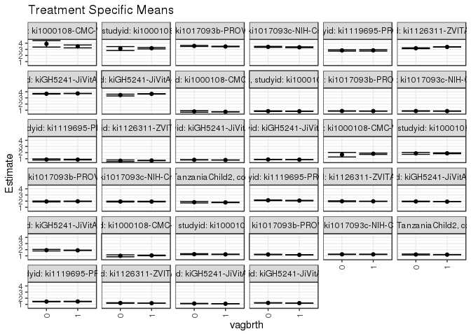

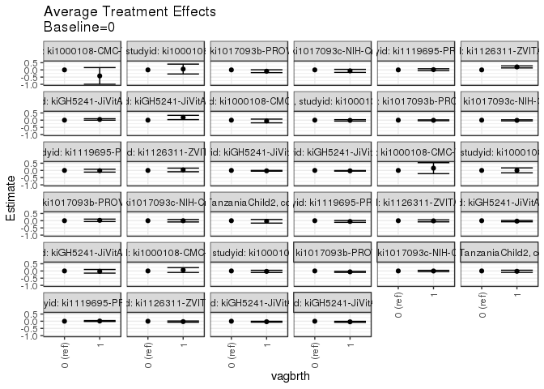

## Results Table

### Parameter: TSM

| agecat | studyid | country | intervention_level | baseline_level | estimate | ci_lower | ci_upper |
| --- | --- | --- | --- | --- | --- | --- | --- |
| 0-3 months | ki1000108-CMC-V-BCS-2002 | INDIA | 0 | NA | 3.8938384 | 3.3665210 | 4.4211557 |
| 0-3 months | ki1000108-CMC-V-BCS-2002 | INDIA | 1 | NA | 3.4754400 | 3.2381366 | 3.7127435 |
| 0-3 months | ki1000108-IRC | INDIA | 0 | NA | 3.1253662 | 2.8041234 | 3.4466090 |
| 0-3 months | ki1000108-IRC | INDIA | 1 | NA | 3.1830123 | 3.0656764 | 3.3003481 |
| 0-3 months | ki1017093b-PROVIDE | BANGLADESH | 0 | NA | 3.5524444 | 3.4638391 | 3.6410497 |
| 0-3 months | ki1017093b-PROVIDE | BANGLADESH | 1 | NA | 3.4614226 | 3.4181857 | 3.5046595 |
| 0-3 months | ki1017093c-NIH-Crypto | BANGLADESH | 0 | NA | 3.4057588 | 3.3251286 | 3.4863891 |
| 0-3 months | ki1017093c-NIH-Crypto | BANGLADESH | 1 | NA | 3.3364376 | 3.2680765 | 3.4047987 |
| 0-3 months | ki1119695-PROBIT | BELARUS | 0 | NA | 2.8212933 | 2.7126366 | 2.9299501 |
| 0-3 months | ki1119695-PROBIT | BELARUS | 1 | NA | 2.8373702 | 2.7209815 | 2.9537589 |
| 0-3 months | ki1126311-ZVITAMBO | ZIMBABWE | 0 | NA | 3.1793891 | 3.1122542 | 3.2465239 |
| 0-3 months | ki1126311-ZVITAMBO | ZIMBABWE | 1 | NA | 3.3872186 | 3.3652016 | 3.4092355 |
| 0-3 months | kiGH5241-JiVitA-3 | BANGLADESH | 0 | NA | 3.6717382 | 3.6227170 | 3.7207595 |
| 0-3 months | kiGH5241-JiVitA-3 | BANGLADESH | 1 | NA | 3.7205595 | 3.7099493 | 3.7311697 |
| 0-3 months | kiGH5241-JiVitA-4 | BANGLADESH | 0 | NA | 3.4612284 | 3.3159590 | 3.6064978 |
| 0-3 months | kiGH5241-JiVitA-4 | BANGLADESH | 1 | NA | 3.6486804 | 3.6166723 | 3.6806885 |
| 3-6 months | ki1000108-CMC-V-BCS-2002 | INDIA | 0 | NA | 1.6578641 | 1.2908296 | 2.0248986 |
| 3-6 months | ki1000108-CMC-V-BCS-2002 | INDIA | 1 | NA | 1.8145027 | 1.7098177 | 1.9191877 |
| 3-6 months | ki1000108-IRC | INDIA | 0 | NA | 1.8759992 | 1.7211905 | 2.0308079 |
| 3-6 months | ki1000108-IRC | INDIA | 1 | NA | 1.8816229 | 1.8116032 | 1.9516427 |
| 3-6 months | ki1017093b-PROVIDE | BANGLADESH | 0 | NA | 1.9456179 | 1.8703805 | 2.0208553 |
| 3-6 months | ki1017093b-PROVIDE | BANGLADESH | 1 | NA | 1.9714251 | 1.9318413 | 2.0110089 |
| 3-6 months | ki1017093c-NIH-Crypto | BANGLADESH | 0 | NA | 1.9313578 | 1.8651680 | 1.9975475 |
| 3-6 months | ki1017093c-NIH-Crypto | BANGLADESH | 1 | NA | 1.9292976 | 1.8773436 | 1.9812517 |
| 3-6 months | ki1066203-TanzaniaChild2 | TANZANIA, UNITED REPUBLIC OF | 0 | NA | 1.8306837 | 1.7088686 | 1.9524987 |
| 3-6 months | ki1066203-TanzaniaChild2 | TANZANIA, UNITED REPUBLIC OF | 1 | NA | 1.7914936 | 1.7535968 | 1.8293904 |
| 3-6 months | ki1119695-PROBIT | BELARUS | 0 | NA | 2.1376883 | 2.0843983 | 2.1909783 |
| 3-6 months | ki1119695-PROBIT | BELARUS | 1 | NA | 2.0857364 | 2.0412890 | 2.1301838 |
| 3-6 months | ki1126311-ZVITAMBO | ZIMBABWE | 0 | NA | 1.9826170 | 1.9179644 | 2.0472696 |
| 3-6 months | ki1126311-ZVITAMBO | ZIMBABWE | 1 | NA | 1.9718828 | 1.9508331 | 1.9929325 |
| 3-6 months | kiGH5241-JiVitA-3 | BANGLADESH | 0 | NA | 1.9492534 | 1.9054729 | 1.9930339 |
| 3-6 months | kiGH5241-JiVitA-3 | BANGLADESH | 1 | NA | 1.9182274 | 1.9073485 | 1.9291064 |
| 3-6 months | kiGH5241-JiVitA-4 | BANGLADESH | 0 | NA | 1.9218509 | 1.7977473 | 2.0459545 |
| 3-6 months | kiGH5241-JiVitA-4 | BANGLADESH | 1 | NA | 1.8966601 | 1.8655086 | 1.9278117 |
| 6-12 months | ki1000108-CMC-V-BCS-2002 | INDIA | 0 | NA | 1.0035607 | 0.8418885 | 1.1652330 |
| 6-12 months | ki1000108-CMC-V-BCS-2002 | INDIA | 1 | NA | 1.0667514 | 1.0168949 | 1.1166079 |
| 6-12 months | ki1000108-IRC | INDIA | 0 | NA | 1.2740636 | 1.2042323 | 1.3438949 |
| 6-12 months | ki1000108-IRC | INDIA | 1 | NA | 1.2433446 | 1.2111839 | 1.2755052 |
| 6-12 months | ki1017093b-PROVIDE | BANGLADESH | 0 | NA | 1.2203239 | 1.1837061 | 1.2569416 |
| 6-12 months | ki1017093b-PROVIDE | BANGLADESH | 1 | NA | 1.1597213 | 1.1402687 | 1.1791739 |
| 6-12 months | ki1017093c-NIH-Crypto | BANGLADESH | 0 | NA | 1.2467213 | 1.2127400 | 1.2807026 |
| 6-12 months | ki1017093c-NIH-Crypto | BANGLADESH | 1 | NA | 1.2430948 | 1.2117560 | 1.2744337 |
| 6-12 months | ki1066203-TanzaniaChild2 | TANZANIA, UNITED REPUBLIC OF | 0 | NA | 1.2195076 | 1.1466372 | 1.2923781 |
| 6-12 months | ki1066203-TanzaniaChild2 | TANZANIA, UNITED REPUBLIC OF | 1 | NA | 1.1941688 | 1.1713434 | 1.2169943 |
| 6-12 months | ki1119695-PROBIT | BELARUS | 0 | NA | 1.4594079 | 1.4183158 | 1.5005001 |
| 6-12 months | ki1119695-PROBIT | BELARUS | 1 | NA | 1.4723743 | 1.4332105 | 1.5115381 |
| 6-12 months | ki1126311-ZVITAMBO | ZIMBABWE | 0 | NA | 1.2239650 | 1.1840817 | 1.2638482 |
| 6-12 months | ki1126311-ZVITAMBO | ZIMBABWE | 1 | NA | 1.1968469 | 1.1854988 | 1.2081950 |
| 6-12 months | kiGH5241-JiVitA-3 | BANGLADESH | 0 | NA | 1.1393116 | 1.1088523 | 1.1697708 |
| 6-12 months | kiGH5241-JiVitA-3 | BANGLADESH | 1 | NA | 1.1048069 | 1.0978980 | 1.1117159 |
| 6-12 months | kiGH5241-JiVitA-4 | BANGLADESH | 0 | NA | 1.2435684 | 1.2118068 | 1.2753301 |
| 6-12 months | kiGH5241-JiVitA-4 | BANGLADESH | 1 | NA | 1.2017422 | 1.1904658 | 1.2130186 |
| 12-24 months | ki1000108-CMC-V-BCS-2002 | INDIA | 0 | NA | 0.7919631 | 0.6659181 | 0.9180081 |
| 12-24 months | ki1000108-CMC-V-BCS-2002 | INDIA | 1 | NA | 0.7357079 | 0.7085235 | 0.7628922 |
| 12-24 months | ki1000108-IRC | INDIA | 0 | NA | 0.8413934 | 0.7969510 | 0.8858359 |
| 12-24 months | ki1000108-IRC | INDIA | 1 | NA | 0.8270610 | 0.8054090 | 0.8487129 |
| 12-24 months | ki1017093b-PROVIDE | BANGLADESH | 0 | NA | 0.8653966 | 0.8386663 | 0.8921270 |
| 12-24 months | ki1017093b-PROVIDE | BANGLADESH | 1 | NA | 0.8553325 | 0.8419419 | 0.8687232 |
| 12-24 months | ki1017093c-NIH-Crypto | BANGLADESH | 0 | NA | 0.8632019 | 0.8322712 | 0.8941325 |
| 12-24 months | ki1017093c-NIH-Crypto | BANGLADESH | 1 | NA | 0.8497761 | 0.8285904 | 0.8709618 |
| 12-24 months | ki1119695-PROBIT | BELARUS | 0 | NA | 0.8757655 | 0.7783640 | 0.9731670 |
| 12-24 months | ki1119695-PROBIT | BELARUS | 1 | NA | 0.8580664 | 0.8024708 | 0.9136620 |
| 12-24 months | ki1126311-ZVITAMBO | ZIMBABWE | 0 | NA | 0.6774452 | 0.5535950 | 0.8012954 |
| 12-24 months | ki1126311-ZVITAMBO | ZIMBABWE | 1 | NA | 0.7120189 | 0.6853451 | 0.7386927 |
| 12-24 months | kiGH5241-JiVitA-3 | BANGLADESH | 0 | NA | 0.8218959 | 0.7975005 | 0.8462913 |
| 12-24 months | kiGH5241-JiVitA-3 | BANGLADESH | 1 | NA | 0.7951069 | 0.7897200 | 0.8004939 |
| 12-24 months | kiGH5241-JiVitA-4 | BANGLADESH | 0 | NA | 0.8767003 | 0.8564739 | 0.8969268 |
| 12-24 months | kiGH5241-JiVitA-4 | BANGLADESH | 1 | NA | 0.8488420 | 0.8427571 | 0.8549269 |

### Parameter: E(Y)

| agecat | studyid | country | intervention_level | baseline_level | estimate | ci_lower | ci_upper |
| --- | --- | --- | --- | --- | --- | --- | --- |
| 0-3 months | ki1000108-CMC-V-BCS-2002 | INDIA | NA | NA | 3.5235318 | 3.3031217 | 3.7439420 |
| 0-3 months | ki1000108-IRC | INDIA | NA | NA | 3.1729204 | 3.0609523 | 3.2848884 |
| 0-3 months | ki1017093b-PROVIDE | BANGLADESH | NA | NA | 3.4826706 | 3.4434873 | 3.5218539 |
| 0-3 months | ki1017093c-NIH-Crypto | BANGLADESH | NA | NA | 3.3649642 | 3.3127253 | 3.4172032 |
| 0-3 months | ki1119695-PROBIT | BELARUS | NA | NA | 2.8355739 | 2.7218468 | 2.9493011 |
| 0-3 months | ki1126311-ZVITAMBO | ZIMBABWE | NA | NA | 3.3690248 | 3.3480527 | 3.3899969 |
| 0-3 months | kiGH5241-JiVitA-3 | BANGLADESH | NA | NA | 3.7184807 | 3.7081255 | 3.7288360 |
| 0-3 months | kiGH5241-JiVitA-4 | BANGLADESH | NA | NA | 3.6382952 | 3.6070008 | 3.6695897 |
| 3-6 months | ki1000108-CMC-V-BCS-2002 | INDIA | NA | NA | 1.8037880 | 1.7029866 | 1.9045894 |
| 3-6 months | ki1000108-IRC | INDIA | NA | NA | 1.8806738 | 1.8168757 | 1.9444719 |
| 3-6 months | ki1017093b-PROVIDE | BANGLADESH | NA | NA | 1.9654454 | 1.9303798 | 2.0005110 |
| 3-6 months | ki1017093c-NIH-Crypto | BANGLADESH | NA | NA | 1.9301440 | 1.8892000 | 1.9710881 |
| 3-6 months | ki1066203-TanzaniaChild2 | TANZANIA, UNITED REPUBLIC OF | NA | NA | 1.7952908 | 1.7590835 | 1.8314981 |
| 3-6 months | ki1119695-PROBIT | BELARUS | NA | NA | 2.0914863 | 2.0503474 | 2.1326251 |
| 3-6 months | ki1126311-ZVITAMBO | ZIMBABWE | NA | NA | 1.9728181 | 1.9527936 | 1.9928426 |
| 3-6 months | kiGH5241-JiVitA-3 | BANGLADESH | NA | NA | 1.9201286 | 1.9096400 | 1.9306171 |
| 3-6 months | kiGH5241-JiVitA-4 | BANGLADESH | NA | NA | 1.8984901 | 1.8679171 | 1.9290631 |
| 6-12 months | ki1000108-CMC-V-BCS-2002 | INDIA | NA | NA | 1.0624474 | 1.0146679 | 1.1102268 |
| 6-12 months | ki1000108-IRC | INDIA | NA | NA | 1.2485668 | 1.2193308 | 1.2778028 |
| 6-12 months | ki1017093b-PROVIDE | BANGLADESH | NA | NA | 1.1731762 | 1.1558671 | 1.1904853 |
| 6-12 months | ki1017093c-NIH-Crypto | BANGLADESH | NA | NA | 1.2446145 | 1.2215001 | 1.2677288 |
| 6-12 months | ki1066203-TanzaniaChild2 | TANZANIA, UNITED REPUBLIC OF | NA | NA | 1.1965957 | 1.1748037 | 1.2183876 |
| 6-12 months | ki1119695-PROBIT | BELARUS | NA | NA | 1.4709224 | 1.4326640 | 1.5091808 |
| 6-12 months | ki1126311-ZVITAMBO | ZIMBABWE | NA | NA | 1.1990544 | 1.1881340 | 1.2099748 |
| 6-12 months | kiGH5241-JiVitA-3 | BANGLADESH | NA | NA | 1.1068872 | 1.1001712 | 1.1136032 |
| 6-12 months | kiGH5241-JiVitA-4 | BANGLADESH | NA | NA | 1.2052762 | 1.1944943 | 1.2160580 |
| 12-24 months | ki1000108-CMC-V-BCS-2002 | INDIA | NA | NA | 0.7397013 | 0.7128622 | 0.7665404 |
| 12-24 months | ki1000108-IRC | INDIA | NA | NA | 0.8294859 | 0.8099817 | 0.8489901 |
| 12-24 months | ki1017093b-PROVIDE | BANGLADESH | NA | NA | 0.8575519 | 0.8455586 | 0.8695452 |
| 12-24 months | ki1017093c-NIH-Crypto | BANGLADESH | NA | NA | 0.8550127 | 0.8373147 | 0.8727107 |
| 12-24 months | ki1119695-PROBIT | BELARUS | NA | NA | 0.8601486 | 0.8069287 | 0.9133686 |
| 12-24 months | ki1126311-ZVITAMBO | ZIMBABWE | NA | NA | 0.7096907 | 0.6834338 | 0.7359476 |
| 12-24 months | kiGH5241-JiVitA-3 | BANGLADESH | NA | NA | 0.7966242 | 0.7913016 | 0.8019468 |
| 12-24 months | kiGH5241-JiVitA-4 | BANGLADESH | NA | NA | 0.8511386 | 0.8452639 | 0.8570132 |

### Parameter: ATE

| agecat | studyid | country | intervention_level | baseline_level | estimate | ci_lower | ci_upper |
| --- | --- | --- | --- | --- | --- | --- | --- |
| 0-3 months | ki1000108-CMC-V-BCS-2002 | INDIA | 0 | 0 | 0.0000000 | 0.0000000 | 0.0000000 |
| 0-3 months | ki1000108-CMC-V-BCS-2002 | INDIA | 1 | 0 | -0.4183983 | -0.9966513 | 0.1598547 |
| 0-3 months | ki1000108-IRC | INDIA | 0 | 0 | 0.0000000 | 0.0000000 | 0.0000000 |
| 0-3 months | ki1000108-IRC | INDIA | 1 | 0 | 0.0576461 | -0.2843549 | 0.3996470 |
| 0-3 months | ki1017093b-PROVIDE | BANGLADESH | 0 | 0 | 0.0000000 | 0.0000000 | 0.0000000 |
| 0-3 months | ki1017093b-PROVIDE | BANGLADESH | 1 | 0 | -0.0910218 | -0.1896136 | 0.0075700 |
| 0-3 months | ki1017093c-NIH-Crypto | BANGLADESH | 0 | 0 | 0.0000000 | 0.0000000 | 0.0000000 |
| 0-3 months | ki1017093c-NIH-Crypto | BANGLADESH | 1 | 0 | -0.0693213 | -0.1750307 | 0.0363881 |
| 0-3 months | ki1119695-PROBIT | BELARUS | 0 | 0 | 0.0000000 | 0.0000000 | 0.0000000 |
| 0-3 months | ki1119695-PROBIT | BELARUS | 1 | 0 | 0.0160769 | -0.0470403 | 0.0791941 |
| 0-3 months | ki1126311-ZVITAMBO | ZIMBABWE | 0 | 0 | 0.0000000 | 0.0000000 | 0.0000000 |
| 0-3 months | ki1126311-ZVITAMBO | ZIMBABWE | 1 | 0 | 0.2078295 | 0.1371766 | 0.2784824 |
| 0-3 months | kiGH5241-JiVitA-3 | BANGLADESH | 0 | 0 | 0.0000000 | 0.0000000 | 0.0000000 |
| 0-3 months | kiGH5241-JiVitA-3 | BANGLADESH | 1 | 0 | 0.0488212 | -0.0013595 | 0.0990020 |
| 0-3 months | kiGH5241-JiVitA-4 | BANGLADESH | 0 | 0 | 0.0000000 | 0.0000000 | 0.0000000 |
| 0-3 months | kiGH5241-JiVitA-4 | BANGLADESH | 1 | 0 | 0.1874520 | 0.0384123 | 0.3364916 |
| 3-6 months | ki1000108-CMC-V-BCS-2002 | INDIA | 0 | 0 | 0.0000000 | 0.0000000 | 0.0000000 |
| 3-6 months | ki1000108-CMC-V-BCS-2002 | INDIA | 1 | 0 | 0.1566386 | -0.2250331 | 0.5383103 |
| 3-6 months | ki1000108-IRC | INDIA | 0 | 0 | 0.0000000 | 0.0000000 | 0.0000000 |
| 3-6 months | ki1000108-IRC | INDIA | 1 | 0 | 0.0056238 | -0.1642835 | 0.1755311 |
| 3-6 months | ki1017093b-PROVIDE | BANGLADESH | 0 | 0 | 0.0000000 | 0.0000000 | 0.0000000 |
| 3-6 months | ki1017093b-PROVIDE | BANGLADESH | 1 | 0 | 0.0258072 | -0.0592077 | 0.1108222 |
| 3-6 months | ki1017093c-NIH-Crypto | BANGLADESH | 0 | 0 | 0.0000000 | 0.0000000 | 0.0000000 |
| 3-6 months | ki1017093c-NIH-Crypto | BANGLADESH | 1 | 0 | -0.0020601 | -0.0862047 | 0.0820845 |
| 3-6 months | ki1066203-TanzaniaChild2 | TANZANIA, UNITED REPUBLIC OF | 0 | 0 | 0.0000000 | 0.0000000 | 0.0000000 |
| 3-6 months | ki1066203-TanzaniaChild2 | TANZANIA, UNITED REPUBLIC OF | 1 | 0 | -0.0391901 | -0.1667639 | 0.0883837 |
| 3-6 months | ki1119695-PROBIT | BELARUS | 0 | 0 | 0.0000000 | 0.0000000 | 0.0000000 |
| 3-6 months | ki1119695-PROBIT | BELARUS | 1 | 0 | -0.0519519 | -0.1143680 | 0.0104642 |
| 3-6 months | ki1126311-ZVITAMBO | ZIMBABWE | 0 | 0 | 0.0000000 | 0.0000000 | 0.0000000 |
| 3-6 months | ki1126311-ZVITAMBO | ZIMBABWE | 1 | 0 | -0.0107342 | -0.0787272 | 0.0572588 |
| 3-6 months | kiGH5241-JiVitA-3 | BANGLADESH | 0 | 0 | 0.0000000 | 0.0000000 | 0.0000000 |
| 3-6 months | kiGH5241-JiVitA-3 | BANGLADESH | 1 | 0 | -0.0310260 | -0.0764744 | 0.0144225 |
| 3-6 months | kiGH5241-JiVitA-4 | BANGLADESH | 0 | 0 | 0.0000000 | 0.0000000 | 0.0000000 |
| 3-6 months | kiGH5241-JiVitA-4 | BANGLADESH | 1 | 0 | -0.0251908 | -0.1520654 | 0.1016839 |
| 6-12 months | ki1000108-CMC-V-BCS-2002 | INDIA | 0 | 0 | 0.0000000 | 0.0000000 | 0.0000000 |
| 6-12 months | ki1000108-CMC-V-BCS-2002 | INDIA | 1 | 0 | 0.0631906 | -0.1059944 | 0.2323757 |
| 6-12 months | ki1000108-IRC | INDIA | 0 | 0 | 0.0000000 | 0.0000000 | 0.0000000 |
| 6-12 months | ki1000108-IRC | INDIA | 1 | 0 | -0.0307190 | -0.1076002 | 0.0461622 |
| 6-12 months | ki1017093b-PROVIDE | BANGLADESH | 0 | 0 | 0.0000000 | 0.0000000 | 0.0000000 |
| 6-12 months | ki1017093b-PROVIDE | BANGLADESH | 1 | 0 | -0.0606025 | -0.1020666 | -0.0191385 |
| 6-12 months | ki1017093c-NIH-Crypto | BANGLADESH | 0 | 0 | 0.0000000 | 0.0000000 | 0.0000000 |
| 6-12 months | ki1017093c-NIH-Crypto | BANGLADESH | 1 | 0 | -0.0036265 | -0.0498526 | 0.0425996 |
| 6-12 months | ki1066203-TanzaniaChild2 | TANZANIA, UNITED REPUBLIC OF | 0 | 0 | 0.0000000 | 0.0000000 | 0.0000000 |
| 6-12 months | ki1066203-TanzaniaChild2 | TANZANIA, UNITED REPUBLIC OF | 1 | 0 | -0.0253388 | -0.1017004 | 0.0510229 |
| 6-12 months | ki1119695-PROBIT | BELARUS | 0 | 0 | 0.0000000 | 0.0000000 | 0.0000000 |
| 6-12 months | ki1119695-PROBIT | BELARUS | 1 | 0 | 0.0129663 | -0.0178261 | 0.0437588 |
| 6-12 months | ki1126311-ZVITAMBO | ZIMBABWE | 0 | 0 | 0.0000000 | 0.0000000 | 0.0000000 |
| 6-12 months | ki1126311-ZVITAMBO | ZIMBABWE | 1 | 0 | -0.0271181 | -0.0685844 | 0.0143482 |
| 6-12 months | kiGH5241-JiVitA-3 | BANGLADESH | 0 | 0 | 0.0000000 | 0.0000000 | 0.0000000 |
| 6-12 months | kiGH5241-JiVitA-3 | BANGLADESH | 1 | 0 | -0.0345046 | -0.0659658 | -0.0030434 |
| 6-12 months | kiGH5241-JiVitA-4 | BANGLADESH | 0 | 0 | 0.0000000 | 0.0000000 | 0.0000000 |
| 6-12 months | kiGH5241-JiVitA-4 | BANGLADESH | 1 | 0 | -0.0418262 | -0.0751252 | -0.0085273 |
| 12-24 months | ki1000108-CMC-V-BCS-2002 | INDIA | 0 | 0 | 0.0000000 | 0.0000000 | 0.0000000 |
| 12-24 months | ki1000108-CMC-V-BCS-2002 | INDIA | 1 | 0 | -0.0562553 | -0.1851984 | 0.0726879 |
| 12-24 months | ki1000108-IRC | INDIA | 0 | 0 | 0.0000000 | 0.0000000 | 0.0000000 |
| 12-24 months | ki1000108-IRC | INDIA | 1 | 0 | -0.0143325 | -0.0637687 | 0.0351037 |
| 12-24 months | ki1017093b-PROVIDE | BANGLADESH | 0 | 0 | 0.0000000 | 0.0000000 | 0.0000000 |
| 12-24 months | ki1017093b-PROVIDE | BANGLADESH | 1 | 0 | -0.0100641 | -0.0399610 | 0.0198328 |
| 12-24 months | ki1017093c-NIH-Crypto | BANGLADESH | 0 | 0 | 0.0000000 | 0.0000000 | 0.0000000 |
| 12-24 months | ki1017093c-NIH-Crypto | BANGLADESH | 1 | 0 | -0.0134258 | -0.0509163 | 0.0240647 |
| 12-24 months | ki1119695-PROBIT | BELARUS | 0 | 0 | 0.0000000 | 0.0000000 | 0.0000000 |
| 12-24 months | ki1119695-PROBIT | BELARUS | 1 | 0 | -0.0176991 | -0.1171797 | 0.0817815 |
| 12-24 months | ki1126311-ZVITAMBO | ZIMBABWE | 0 | 0 | 0.0000000 | 0.0000000 | 0.0000000 |
| 12-24 months | ki1126311-ZVITAMBO | ZIMBABWE | 1 | 0 | 0.0345737 | -0.0921163 | 0.1612637 |
| 12-24 months | kiGH5241-JiVitA-3 | BANGLADESH | 0 | 0 | 0.0000000 | 0.0000000 | 0.0000000 |
| 12-24 months | kiGH5241-JiVitA-3 | BANGLADESH | 1 | 0 | -0.0267890 | -0.0516412 | -0.0019368 |
| 12-24 months | kiGH5241-JiVitA-4 | BANGLADESH | 0 | 0 | 0.0000000 | 0.0000000 | 0.0000000 |
| 12-24 months | kiGH5241-JiVitA-4 | BANGLADESH | 1 | 0 | -0.0278583 | -0.0487040 | -0.0070126 |